# Module 6 - The Transportation Model

Lokesh Jetangi

2023-10-14

```r
#Install and load required packages
#install.packages("kableExtra")
#install.packages("magrittr")
library(kableExtra)
library(magrittr)
```

```r
Data_tab<-matrix(c(20,14,25,400,100,
 12,15,14,300,125,
 10,12,15,500,150,
 80,90,70,NA,NA),nrow = 4,byrow = TRUE)
colnames(Data_tab)<-c("Warehouse 1","Warehouse 2","Warehouse 3","Production Cost","Production Capacity")
rownames(Data_tab)<-c("plant A","plant B","plant C","Monthly Demand")
Data_tab<-as.table(Data_tab)

Data_tab%>%
 kable()%>%
 kable_classic()%>%
 column_spec(2,border_left = TRUE) %>%
 #column_spec(6,border_left = TRUE)%>%
row_spec(3,extra_css = "border-bottom:dotted;")
```

|  | Warehouse 1 | Warehouse 2 | Warehouse 3 | Production Cost | Production Capacity |
| --- | --- | --- | --- | --- | --- |
| plant A | 20 | 14 | 25 | 400 | 100 |
| plant B | 12 | 15 | 14 | 300 | 125 |
| plant C | 10 | 12 | 15 | 500 | 150 |
| Monthly Demand | 80 | 90 | 70 | NA | NA |

```r
#Install and load the igraph library
#install.packages("igraph")
library(igraph)
sources <- c("PA", "PB", "PC")
supply <- c(100, 125, 150)

destinations <- c("W1", "W2", "W3")
demand <- c(80, 90, 70)
```

```r
#create an empty graph with the total number of vertices
total_vertices<-length(sources)+length(destinations)
g<-graph.empty(n=total_vertices,directed=TRUE)
```

```r
#Add vertices for sources and destinations
V(g)$name <- c(sources, destinations)
```

```r
#Create edges from each source to each destination
for (i in 1:length(sources)) {
 for (j in 1:length(destinations)) {
 weight <- min(supply[i], demand[j])
 if (weight > 0) {
 g <- add_edges(g, edges = c(sources[i], destinations[j]), weight = weight)
 }
 }
}
```

```r
#Define a layout with x-coordinates for sources and destinations
layout <- layout_in_circle(g, order = c(1, 2, 3, 4, 5, 6))
```

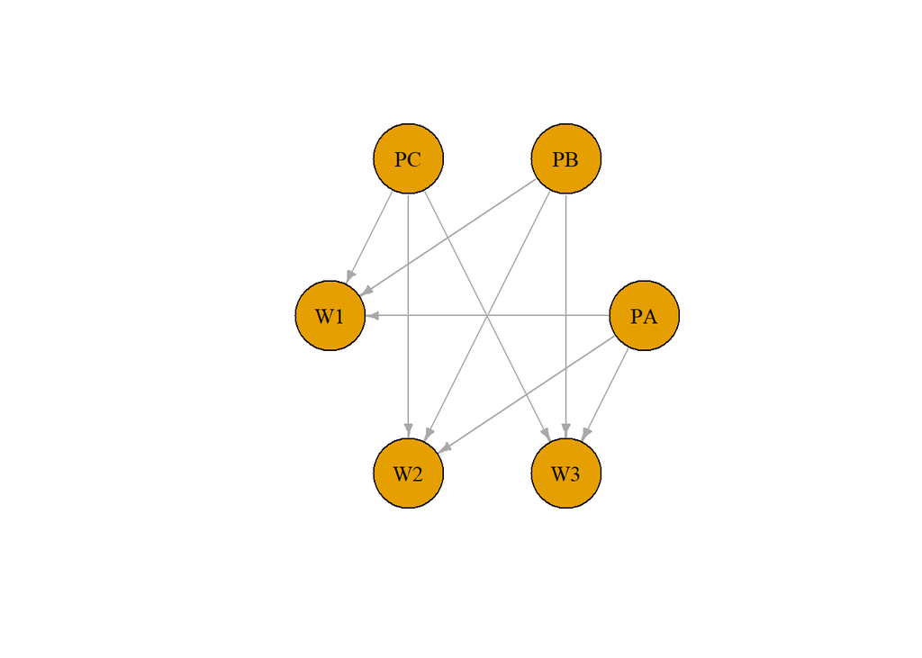

```r
#Plot the graph with directed edges and the custom layout
plot(g, layout = layout, vertex.label.color = "black", vertex.size = 45, edge.arrow.size = 0.5)
```

**1. Formulate and solve this transportation problem using R**

##In this problem, there are 375 total supplies available, but there are only 240 available warehouse spaces. Therefore, we must build a fictitious demander or warehousing capacity. # The Objective Function is to Minimize the Transportation cost

$$Min\ TC
=\hspace{1cm}420X_{11}+414X_{12}+425X_{13}+0X_{14}+\\\hspace{3cm}312X_{21}+315X_{22}+314X_{23}+0X_{24}+\\\hspace{2.6cm}510X_{31}+512X_{32}+515X_{33}+0X_{34}$$
# constraints ##Supply Constraints
$$X_{11}
+ X_{12} + X_{13} + X_{14} \le 100$$
$$X_{21} + X_{22} + X_{23} + X_{24} \le 125$$
$$X_{31} + X_{32} + X_{33} +
X_{34} \le 150$$
##Demand Constraints
$$X_{11} + X_{21} + X_{31} \ge 80$$
$$X_{12} + X_{22} + X_{32} \ge 90$$
$$X_{13} + X_{23} + X_{33} \ge 70$$
$$X_{14} + X_{24} + X_{34} \ge 135$$
##Non-negativity constraints
$$x_{ij} \ge 0
\hspace{0.3cm} where \hspace{.3cm} i = 1,2,3 \hspace{0.3cm} and
\hspace{0.3cm} j =1,2,3,4$$

```r
#install.packages("lpSolve")
library(lpSolve)
Data_tab<-matrix(c(420,414,425,0,100,
 312,315,314,0,125,
 510,512,515,0,150,
 80,90,70,135,375),nrow = 4,byrow = TRUE)
colnames(Data_tab)<-c("Warehouse 1","Warehouse 2","Warehouse 3","Dummy","Production Capacity")
rownames(Data_tab)<-c("plant A","plant B","plant C","Monthly Demand")
Data_tab<-as.table(Data_tab)

Data_tab%>%
 kable()%>%
 kable_classic()%>%
column_spec(2,border_left = TRUE) %>%
column_spec(6,border_left = TRUE)%>%
row_spec(3,extra_css = "border-bottom:dotted;")
```

|  | Warehouse 1 | Warehouse 2 | Warehouse 3 | Dummy | Production Capacity |
| --- | --- | --- | --- | --- | --- |
| plant A | 420 | 414 | 425 | 0 | 100 |
| plant B | 312 | 315 | 314 | 0 | 125 |
| plant C | 510 | 512 | 515 | 0 | 150 |
| Monthly Demand | 80 | 90 | 70 | 135 | 375 |

#Now Demand = supply = 375

```r
cost_matrix <- matrix(c(420, 414, 425,0,
                        312, 315, 314,0,
                        510, 512, 515,0), nrow = 3, byrow = TRUE)
cost_matrix
```

```
##      [,1] [,2] [,3] [,4]
## [1,]  420  414  425    0
## [2,]  312  315  314    0
## [3,]  510  512  515    0
```

```r
row.signs <- rep("<=", 3)
row.rhs <- c(100,125,150)
```

```r
col.signs <- rep(">=", 4)
col.rhs <- c(80,90,70,135)
```

```r
lp_transport <- lp.transport(cost_matrix, "min", row.signs, row.rhs, col.signs, col.rhs)
lp_transport
```

```
## Success: the objective function is 88250
```

```r
lp_transport$solution
```

```
##      [,1] [,2] [,3] [,4]
## [1,]   10   90    0    0
## [2,]   55    0   70    0
## [3,]   15    0    0  135
```

**2. Formulate the dual of this transportation problem**

##The dual objective function is the value addition (VA) for the suppliers. The positive part is what the supplier gets by shipping goods to the demanders and the negative part is the cost of producing goods. The difference is the VA or profit. Thus the dual problem is to maximize VA.

#The objective function of the dual is then

$$Max\ Z = 80v_1 + 90v_2 + 70v_3 −
100u_1 − 125u_2 − 150u_3$$
#Constarints
$$v_j - u_i \ge cij$$
#The plant A produces goods for 3 possible warehouse:
$$v_1 - u_1
\ge c_{11}\hspace{0.2cm} = 420$$
$$v_2 - u_1 \ge c_{12} \hspace{0.2cm} = 414$$
$$v_3 - u_1 \ge c_{13} \hspace{0.2cm} OR = 425$$
The plant B produces goods for 3 possible warehouse:

$$v_1 - u_2 \ge c_{21}\hspace{0.2cm} =
312$$
$$v_2 - u_2 \ge
c_{22}\hspace{0.2cm} = 315$$
$$v_3 -
u_2 \ge c_{23}\hspace{0.2cm} = 314$$
The plant C produces goods for 3 possible warehouse:

$$v_1 - u_3 \ge c_{31}\hspace{0.2cm} =
510$$
$$v_2 - u_3 \ge
c_{32}\hspace{0.2cm} = 512$$
$$v_3 -
u_3 \ge c_{33}\hspace{0.2cm} = 515$$
The plant A produces goods for 3 possible warehouse.

$$v11 − u1 \ge c11 (OR) v11 − 400 \ge 20
(OR) v11 \ge 420$$
$$v12 − u1 \ge c12
( OR) v12− 400 \ge 14 (OR) v12\ge414$$
$$v13− u1\ge c13 (OR) v13− 400 \ge 25 (OR) v13 \ge
425$$
The plant B produces goods for 3 possible warehouse.that is

$$v21 − u2 \ge c21 (OR) v21 − 300 \ge 12
(OR) v21 \ge 312$$
$$v22 − u2 \ge c22
(OR) v22 − 300 \ge 15 (OR) v22 \ge 315$$
$$v23 − u2 \ge c23 (OR) v23 − 300 \ge 14 (OR) v23
\ge 314$$
The plant C produces goods for 3 possible warehouse.that is
$$v31−u3\ge c31 (OR) v31 −
500 \ge 10 (OR) v31 \ge 510$$
$$v32 −
u3\ge c32 (OR) v32 − 500 \ge 12 (OR) v32 \ge 512$$
$$v33 − u3 \ge c33 (OR) v33 − 500 \ge 15 (OR) v33
\ge 515$$
Non-negativity of the decision variables:
$$v_{ij} \ge 0 \hspace{0.1cm} where \hspace{0.1cm}
i\hspace{0.1cm} =1,2,3 \hspace{0.1cm}and\hspace{0.1cm}j=1,2,3
\hspace{0.1cm} and \hspace{0.1cm} u_i \ge 0
\hspace{0.1cm}where\hspace{0.1cm}i\hspace{0.1cm}=1,2,3$$
**3.Make an economic interpretation of the dual**

$$1.\hspace{0.1cm}MR =
MC\hspace{0.1cm}rule$$
#Our dual constraint is $v_{j} - u_{i} \ge c_{ij}$ This means $v_{j} \ge c_{ij} + u_{i}$

**The per-unit revenue earned by selling one unit of the product is shown on the left side. In economics, we refer to this as marginal revenue. The cost per unit of producing and shipping goods to Warehouse J is shown on the right side. The Plants should increase production and continue shipping the prouct until $\hspace{.2cm}MR \ge MC\hspace{.2cm}$ and Decreases production of the $\hspace{.2cm}MR \le MC\hspace{.2cm}$**

**These two situations are dynamic, and it may be said that neither the producer nor the output changes. We refer to this as the equilibrium for profit maximization.**

**The per-unit revenue earned from the sale of one unit of the product is shown on the left side of the graph (v13). This is what economists refer to as marginal revenue.**

**The production and delivery costs per unit are shown on the right hand side (c13+u1OR$425).Marginal cost is the term for this.**

**As long as demand outpaces supply, the supplier will continue to increase production and transport to the locations. When demand is weak, or when there is a surplus of inventory, the supplier, on the other hand, scales back production and shipping.Both of these circumstances are dynamic, with either an increase or a fall in productivity. When inventory levels are optimal, or when demand and supply are equal, the producer does not alter production in any way. We refer to this as the equilibrium for profit maximization. Using our examples, we may conclude that since the plant A - warehouse3 unit will bring in more money than or equal to 425, the company should keep making the (v13) unit. Reduced output may be more beneficial for the company if sales falls below this mark.** **Thus, the dual goal of profit maximization and optimal allocation and routing strategies is the same as the transportation cost minimization problem.**

**2.Hiring or not Hiring shipping company for shipping goods**

**1)Not Hiring :**

Let’s take into account the equation
$$v13-u1\ge c13$$
(v13 −u1 ≥ c13), which indicates the expense of shipping goods from plant A to destination 3.Straight from the source to the destination, the provider delivers the commodities. Therefore, handling transportation internally is preferable if the overall cost is lower. This choice is subject to a thorough examination of all associated expenses, including fixed and variable costs as well as any supplemental service charges or out-of-pocket expenses that may be incurred.

2)Hiring :
$$TC_{in−house} \ge
TC_{hire}$$